# Barebell Lifts

Stephanie Conway

2022-06-16

## Barebell Lifts Classification

In this work we will analyse data from accelerometers on the belt, forearm, arm, and dumbbell of 6 participants to quantify how well they perform barbell lifts correctly and incorrectly in 5 different ways. Class A corresponds to the specified execution of the exercise, while the other 4 classes correspond to common mistakes.

The sourse of the dataset is: Velloso, E.; Bulling, A.; Gellersen, H.; Ugulino, W.; Fuks, H. Qualitative Activity Recognition of Weight Lifting Exercises. Proceedings of 4th International Conference in Cooperation with SIGCHI (Augmented Human ’13) . Stuttgart, Germany: ACM SIGCHI, 2013.

```r
set.seed(12640)
```

### Reading in data

```r
training <- read.csv("pml-training.csv", na.strings = c("NA", "","#DIV/0!"))
testing <- read.csv("pml-testing.csv", na.strings = c("NA", "","#DIV/0!"))
```

### Preprocessing

First we remove the columns that have over 90% NA values (sparse columns) and make our outcome (classe) a factor

```r
training <- training[ , colSums(is.na(training)) < 0.9*nrow(training)]
training$classe <- factor(training$classe)
```

We separate the training set further into a validation and true training set and remove the first 7 columns as they reflect identification of the data point and not the measurement (initial tree was able to classify based on the index alone with 66 % accuracy)

```r
training <- training[,8:60]
inTrain <- createDataPartition(training$classe, p=0.7, list=FALSE)
train <- training[inTrain,]
valid <- training[-inTrain,]
```

### Base model: Classification Tree

Since this is a classification problem we choose to use tree-based algorithms, starting with a classification tree. The caret package implements the rpart method with cp as the tuning parameter. caret by default will prune the tree based on a default run it makes on a default parameter grid.

```r
fit1 <- train(classe~., data=training, method='rpart')
```

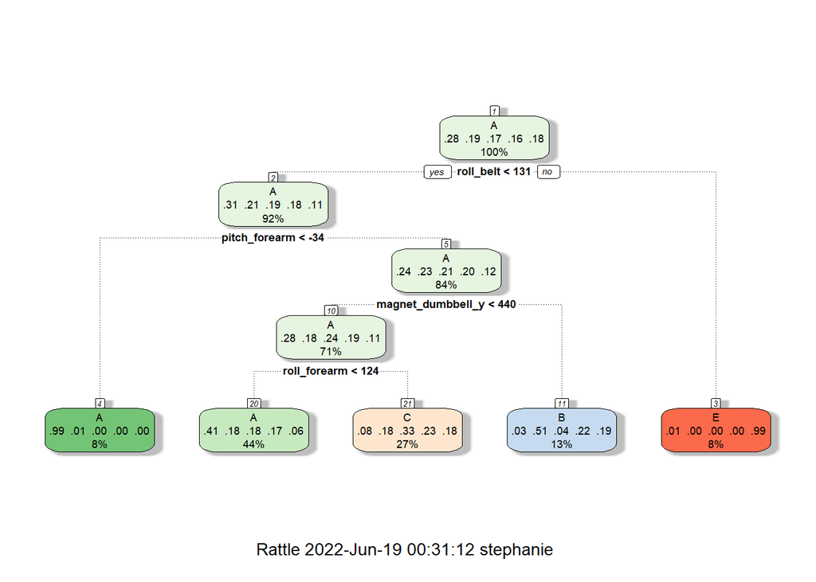

```r
fancyRpartPlot(fit1$finalModel)
```

```r
confusionMatrix(valid$classe,predict(fit1,valid))
```

```
## Confusion Matrix and Statistics
##
##           Reference
## Prediction    A    B    C    D    E
##          A 1537   21  114    0    2
##          B  464  374  301    0    0
##          C  485   39  502    0    0
##          D  422  190  352    0    0
##          E  149  142  314    0  477
##
## Overall Statistics
##
##                Accuracy : 0.4911
##                  95% CI : (0.4782, 0.5039)
##     No Information Rate : 0.5195
##     P-Value [Acc > NIR] : 1
##
##                   Kappa : 0.3349
##
##  Mcnemar's Test P-Value : NA
##
## Statistics by Class:
##
##                      Class: A Class: B Class: C Class: D Class: E
## Sensitivity            0.5028  0.48825   0.3171       NA  0.99582
## Specificity            0.9516  0.85056   0.8782   0.8362  0.88809
## Pos Pred Value         0.9182  0.32836   0.4893       NA  0.44085
## Neg Pred Value         0.6390  0.91740   0.7775       NA  0.99958
## Prevalence             0.5195  0.13016   0.2690   0.0000  0.08139
## Detection Rate         0.2612  0.06355   0.0853   0.0000  0.08105
## Detection Prevalence   0.2845  0.19354   0.1743   0.1638  0.18386
## Balanced Accuracy      0.7272  0.66940   0.5977       NA  0.94196
```

The classification tree has an accuracy of 0.4911 (*estimated oob error of 51%*) which is rather low.  
We will use this as our baseline to see if we can improve upon this.

### Random Forest Classification

To run random forest I will enable parallel processing on my computer

```r
cluster <- makeCluster(detectCores() - 1)
registerDoParallel(cluster)
```

We will train the random forest model with K-fold cross validation with 5 folds. To do so we have to set the arguments from the trainControl function. Then we train our model based on our training set.

```r
fitControl <- trainControl(method = "cv", number = 5, allowParallel = TRUE)
system.time(fit2 <- train(classe~., data=train, method='rf', trControl = fitControl, importance = T))
```

```
##    user  system elapsed
##   75.94    0.50  658.75
```

```r
fit2
```

```
## Random Forest
##
## 13737 samples
##    52 predictor
##     5 classes: 'A', 'B', 'C', 'D', 'E'
##
## No pre-processing
## Resampling: Cross-Validated (5 fold)
## Summary of sample sizes: 10989, 10990, 10990, 10989, 10990
## Resampling results across tuning parameters:
##
##   mtry  Accuracy   Kappa
##    2    0.9898813  0.9871993
##   27    0.9898086  0.9871080
##   52    0.9807819  0.9756875
##
## Accuracy was used to select the optimal model using the largest value.
## The final value used for the model was mtry = 2.
```

And now we must deregister the parallel processing cluster

```r
stopCluster(cluster)
registerDoSEQ()
```

The accuracy of the random forest classification, based on the validation set, is

```r
confusionMatrix(valid$classe,predict(fit2,valid))
```

```
## Confusion Matrix and Statistics
##
##           Reference
## Prediction    A    B    C    D    E
##          A 1674    0    0    0    0
##          B    2 1136    1    0    0
##          C    0    3 1021    2    0
##          D    0    0   19  945    0
##          E    0    0    0    0 1082
##
## Overall Statistics
##
##                Accuracy : 0.9954
##                  95% CI : (0.9933, 0.997)
##     No Information Rate : 0.2848
##     P-Value [Acc > NIR] : < 2.2e-16
##
##                   Kappa : 0.9942
##
##  Mcnemar's Test P-Value : NA
##
## Statistics by Class:
##
##                      Class: A Class: B Class: C Class: D Class: E
## Sensitivity            0.9988   0.9974   0.9808   0.9979   1.0000
## Specificity            1.0000   0.9994   0.9990   0.9962   1.0000
## Pos Pred Value         1.0000   0.9974   0.9951   0.9803   1.0000
## Neg Pred Value         0.9995   0.9994   0.9959   0.9996   1.0000
## Prevalence             0.2848   0.1935   0.1769   0.1609   0.1839
## Detection Rate         0.2845   0.1930   0.1735   0.1606   0.1839
## Detection Prevalence   0.2845   0.1935   0.1743   0.1638   0.1839
## Balanced Accuracy      0.9994   0.9984   0.9899   0.9970   1.0000
```

While the accuracy is outstanding, I think it would be interesting to see which features really affect the classification. To this end, we will run the rfcv method.

```r
cluster <- makeCluster(detectCores() - 1)
registerDoParallel(cluster)
train.x <-subset(train, select = -c(classe))
fitControl <- trainControl(allowParallel = TRUE)
result <- rfcv(train.x,train$classe, cv.fold=3, trControl = fitControl)
stopCluster(cluster)
registerDoSEQ()
result$error.cv
```

```
##          52          26          13           6           3           1
## 0.007497998 0.010191454 0.015651161 0.026279391 0.138749363 0.438669287
```

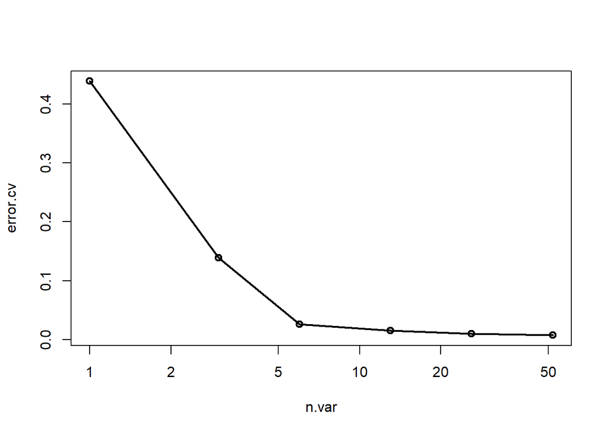

```r
with(result, plot(n.var, error.cv, log="x", type="o", lwd=2))
```

The error.cv decreases significantly between 1 to 6 features and then decreases much more slowly after that. In an effort to balance bias and variance error we will try to create a model with the 26 most important features which corresponds to an error.cv of 1% which is only nominally worse that the error.cv of 0.75% for all 52 features.

```r
new_train_x = train[,rownames(varImp(fit2)$importance)[1:26]]
cluster <- makeCluster(detectCores() - 1)
registerDoParallel(cluster)
fitControl <- trainControl(method = "cv", number = 5, allowParallel = TRUE)
system.time(fit3 <- train(x = new_train_x, y=train$classe,trControl = fitControl))
```

```
##    user  system elapsed
##   22.28    0.28  173.17
```

```r
stopCluster(cluster)
registerDoSEQ()
```

Now let’s compare the accuracy on our validation set.

```r
confusionMatrix(valid$classe,predict(fit3,valid))
```

```
## Confusion Matrix and Statistics
##
##           Reference
## Prediction    A    B    C    D    E
##          A 1651    8    8    6    1
##          B    6 1129    4    0    0
##          C    4   22  988   10    2
##          D    0    1   20  941    2
##          E    1    1    3    9 1068
##
## Overall Statistics
##
##                Accuracy : 0.9816
##                  95% CI : (0.9779, 0.9849)
##     No Information Rate : 0.2824
##     P-Value [Acc > NIR] : < 2.2e-16
##
##                   Kappa : 0.9768
##
##  Mcnemar's Test P-Value : 0.0008348
##
## Statistics by Class:
##
##                      Class: A Class: B Class: C Class: D Class: E
## Sensitivity            0.9934   0.9724   0.9658   0.9741   0.9953
## Specificity            0.9946   0.9979   0.9922   0.9953   0.9971
## Pos Pred Value         0.9863   0.9912   0.9630   0.9761   0.9871
## Neg Pred Value         0.9974   0.9933   0.9928   0.9949   0.9990
## Prevalence             0.2824   0.1973   0.1738   0.1641   0.1823
## Detection Rate         0.2805   0.1918   0.1679   0.1599   0.1815
## Detection Prevalence   0.2845   0.1935   0.1743   0.1638   0.1839
## Balanced Accuracy      0.9940   0.9852   0.9790   0.9847   0.9962
```

We will now run our selected model (fit3) on the testing dataset.

```r
testing.prediction <- predict(fit3,testing)
testing.prediction
```

```
##  [1] B A B A A E D B A A B C B A E E A B B B
## Levels: A B C D E
```